# Linear Discriminant Analysis in R

Author : [Lin](https://www.linkedin.com/in/lincingsheng/)

# Introduction

本篇 LDA with R 是在我做完LDA參考筆記後，利用範例資料集與 Kaggle 中實際資料做 LDA 演練。重點僅放在如何在 R 中實現 LDA 模型，對於範例資料集與 Kaggle 資料所建立的模型，不會調整或是優化模型。

所使用的 Dataset 可以在這邊下載:

- Smarket(`ISRL` 套件中)
- [Kaggle_creictcard](https://www.kaggle.com/dalpozz/creditcardfraud)

# Smarket 範例資料

## Modeling

`LDA` 的在 R 的 `MASS` 套件中，可以直接呼叫 `lda` 即可。首先我們以 An Introduction to Statistical Learning 書中的範例來練習如何使用LDA做分類的問題。

首先我們可以以下載入套件：

- `magrittr`、`tidyverse`：pipeline所需的運算子
- `MASS`：包含 LDA 的 function
- `ISLR`：包含範例資料集 `Smarket`，其中 `Direction` 當做目標變數(up, down)

我們先將 Smarket 分成 Train and Test，在使用 train 丟進 lda 去建模。我們先以`p = 2`作示範，因此LDA的 Features Space ≤ min(2-1, 2) = 1。

`?lda` 可以參考一下參數的設定：

- `prior`：可以預先設定 Up & Down $\pi_{k}$
- `CV`：是否要做CV

```r
> library(magrittr)
> library(rpart)
> library(MASS)
> library(ISLR)
> library(tidyverse)
> train <- Smarket %>% filter(Year < 2005)
> lda.fit <- lda(Direction ~ Lag1 + Lag2, data = train)
> lda.fit %>% attributes()
```

```
$names
 [1] "prior"   "counts"  "means"   "scaling" "lev"     "svd"     "N"
 [8] "call"    "terms"   "xlevels"

$class
[1] "lda"
```

因 Fisher approach 有 Dimension Reduction 的好處，透過 $A'X$ = $T$ 將原先的 Vaiables 投影到新的 Feature Space。在 ISRL 的範例中，因為 r = 1，因此等於將原先的 Lag1、Lag2 投影到 LD1 上。

```r
> lda.fit$scaling
```

```
            LD1
Lag1 -0.6420190
Lag2 -0.5135293
```

Group means :

```r
> lda.fit$means
```

```
            Lag1        Lag2
Down  0.04279022  0.03389409
Up   -0.03954635 -0.03132544
```

## Predicttion

建立一個Test dataset:

- Smarket.2005
- Direction.2005

用 Test 資料 `Smarket.2005` 進行預測，並且在跟真實答案 `Direction.2005` 作比較。

```r
> Smarket.2005 <- Smarket %>% filter(Year >= 2005)
> Direction.2005 <- Smarket %>% filter(Year >= 2005) %$% Direction
> lda.pred = predict(lda.fit, Smarket.2005)
> names(lda.pred)
```

```
[1] "class"     "posterior" "x"
```

計算 ACC 正確率

```r
> lda.class <- lda.pred$class
> table(lda.class,Direction.2005)
```

```
         Direction.2005
lda.class Down  Up
     Down   35  35
     Up     76 106
```

```r
> mean(lda.class == Direction.2005)
```

```
[1] 0.5595238
```

從 ACC 看出其實分類的成效不太好，從圖形上也可以略知一二。我們將 Lag1、Lag2 投影到 LD1 ，可以看出兩類在 LD1 無法切割開來。

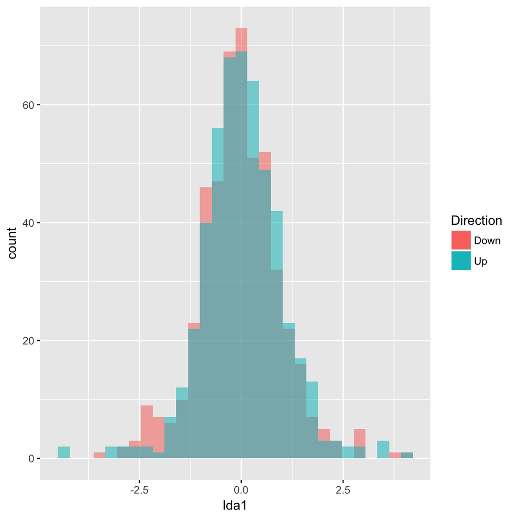

```r
> train.lda <- data.frame(
+   lda1 = train$Lag1*lda.fit$scaling[1] + train$Lag2*lda.fit$scaling[2],
+   Direction = train$Direction
+ )
> ggplot(train.lda, aes(x = lda1, fill = Direction)) +
+   geom_histogram(position="identity", aes(alpha = 0.1))+
+   geom_blank()+
+   guides(alpha = F)
```

lda 模型的物件中，也提供 posterior ，可以自行定義 Threshold 來進行歸類。

```r
> head(lda.pred$posterior)
```

```
       Down        Up
1 0.4901792 0.5098208
2 0.4792185 0.5207815
3 0.4668185 0.5331815
4 0.4740011 0.5259989
5 0.4927877 0.5072123
6 0.4938562 0.5061438
```

# Kaggle Challenge !

接下來我們來試試看將 lda 應用至 kaggle 選定的資料中。接下來我們會簡單演練一次：資料整理、模型建立、模型評估 整個過程，除了 Accuracy Rate 以外，我還嘗試了 `AUC` 以及 Kaggle 用來評分的 `AUCPR` 指標。那我們就開始吧！

欄位介紹：

- V1, V2, … V28 are the principal components obtained with PCA
- Time、Amount：時間(秒為單位，指從第一刻開始發生每筆交易所經過的秒數)、交易金額
- Class：1 = Fraud, 0 = otherwise

```r
> library(data.table)
> library(DT)
> library(ROCR)
> library(highcharter)
> kaggle_credictcard <- fread('dataset/kaggle_creditcard.csv')
```

```
Read 42.1% of 284807 rows
Read 284807 rows and 31 (of 31) columns from 0.140 GB file in 00:00:04
```

```r
> kaggle_credictcard %>% head %>% datatable() %>% formatRound(2:29, digits = 4)
```

|  | Time | V1 | V2 | V3 | V4 | V5 | V6 | V7 | V8 | V9 | V10 | V11 | V12 | V13 | V14 | V15 | V16 | V17 | V18 | V19 | V20 | V21 | V22 | V23 | V24 | V25 | V26 | V27 | V28 | … |
| --- | --- | --- | --- | --- | --- | --- | --- | --- | --- | --- | --- | --- | --- | --- | --- | --- | --- | --- | --- | --- | --- | --- | --- | --- | --- | --- | --- | --- | --- | --- |
| 1 | 0 | -1.3598071336738 | -0.0727811733098497 | 2.53634673796914 | 1.37815522427443 | -0.338320769942518 | 0.462387777762292 | 0.239598554061257 | 0.0986979012610507 | 0.363786969611213 | 0.0907941719789316 | -0.551599533260813 | -0.617800855762348 | -0.991389847235408 | -0.311169353699879 | 1.46817697209427 | -0.470400525259478 | 0.207971241929242 | 0.0257905801985591 | 0.403992960255733 | 0.251412098239705 | -0.018306777944153 | 0.277837575558899 | -0.110473910188767 | 0.0669280749146731 | 0.128539358273528 | -0.189114843888824 | 0.133558376740387 | -0.0210530534538215 | … |
| 2 | 0 | 1.19185711131486 | 0.26615071205963 | 0.16648011335321 | 0.448154078460911 | 0.0600176492822243 | -0.0823608088155687 | -0.0788029833323113 | 0.0851016549148104 | -0.255425128109186 | -0.166974414004614 | 1.61272666105479 | 1.06523531137287 | 0.48909501589608 | -0.143772296441519 | 0.635558093258208 | 0.463917041022171 | -0.114804663102346 | -0.183361270123994 | -0.145783041325259 | -0.0690831352230203 | -0.225775248033138 | -0.638671952771851 | 0.101288021253234 | -0.339846475529127 | 0.167170404418143 | 0.125894532368176 | -0.00898309914322813 | 0.0147241691924927 | … |
| 3 | 1 | -1.35835406159823 | -1.34016307473609 | 1.77320934263119 | 0.379779593034328 | -0.503198133318193 | 1.80049938079263 | 0.791460956450422 | 0.247675786588991 | -1.51465432260583 | 0.207642865216696 | 0.624501459424895 | 0.066083685268831 | 0.717292731410831 | -0.165945922763554 | 2.34586494901581 | -2.89008319444231 | 1.10996937869599 | -0.121359313195888 | -2.26185709530414 | 0.524979725224404 | 0.247998153469754 | 0.771679401917229 | 0.909412262347719 | -0.689280956490685 | -0.327641833735251 | -0.139096571514147 | -0.0553527940384261 | -0.0597518405929204 | … |
| 4 | 1 | -0.966271711572087 | -0.185226008082898 | 1.79299333957872 | -0.863291275036453 | -0.0103088796030823 | 1.24720316752486 | 0.23760893977178 | 0.377435874652262 | -1.38702406270197 | -0.0549519224713749 | -0.226487263835401 | 0.178228225877303 | 0.507756869957169 | -0.28792374549456 | -0.631418117709045 | -1.0596472454325 | -0.684092786345479 | 1.96577500349538 | -1.2326219700892 | -0.208037781160366 | -0.108300452035545 | 0.00527359678253453 | -0.190320518742841 | -1.17557533186321 | 0.647376034602038 | -0.221928844458407 | 0.0627228487293033 | 0.0614576285006353 | … |
| 5 | 2 | -1.15823309349523 | 0.877736754848451 | 1.548717846511 | 0.403033933955121 | -0.407193377311653 | 0.0959214624684256 | 0.592940745385545 | -0.270532677192282 | 0.817739308235294 | 0.753074431976354 | -0.822842877946363 | 0.53819555014995 | 1.3458515932154 | -1.11966983471731 | 0.175121130008994 | -0.451449182813529 | -0.237033239362776 | -0.0381947870352842 | 0.803486924960175 | 0.408542360392758 | -0.00943069713232919 | 0.79827849458971 | -0.137458079619063 | 0.141266983824769 | -0.206009587619756 | 0.502292224181569 | 0.219422229513348 | 0.215153147499206 | … |
| 6 | 2 | -0.425965884412454 | 0.960523044882985 | 1.14110934232219 | -0.168252079760302 | 0.42098688077219 | -0.0297275516639742 | 0.476200948720027 | 0.260314333074874 | -0.56867137571251 | -0.371407196834471 | 1.34126198001957 | 0.359893837038039 | -0.358090652573631 | -0.137133700217612 | 0.517616806555742 | 0.401725895589603 | -0.0581328233640131 | 0.0686531494425432 | -0.0331937877876282 | 0.0849676720682049 | -0.208253514656728 | -0.559824796253248 | -0.0263976679795373 | -0.371426583174346 | -0.232793816737034 | 0.105914779097957 | 0.253844224739337 | 0.0810802569229443 | … |

## Preliminary Analysis & Pre-processing

注意！此份資料相當不平衡 (Imbalance Case)。

```r
> kaggle_credictcard %>%
+   group_by(Class) %>%
+   tally %>%
+   mutate(prop = n/(sum(n))) -> tmp
> highchart() %>%
+   hc_title(text = "Fraud Proportion") %>%
+   hc_subtitle(text = "Fraud is extremly less") %>%
+   hc_add_series_labels_values(labels = tmp$Class, values = tmp$n,
+                               name = "Bar", type = "pie")
```

[interactive chart not shown]

接下來要將資料分成 Train and Test，但先 check 有沒有重複的 Observation。

發現有重複的值，利用 `distinct` function 將重複值去除，命名成 `kaggle_credictcard_no_dup`。在 Check 一次有沒有重複值，得到 `False`

```r
> any(duplicated(kaggle_credictcard)) #yes!
```

```
[1] TRUE
```

```r
> kaggle_credictcard %>%
+   distinct(.) -> kaggle_credictcard_no_dup # conflict to MASS
> any(duplicated(kaggle_credictcard_no_dup)) #False
```

```
[1] FALSE
```

清除完重複值之後，呼叫 `sample_frac` 抽取 `kaggle_credictcard_no_dup` 70% 的資料為 `train`。再呼叫 `setdiff` 將剩餘的資料(也就是`kaggle_credictcard_no_dup` 與 `Train` 取補集合)為 `test`。並且都將 `Time` and `Amount` 去除掉。

```r
> train <- sample_frac(kaggle_credictcard_no_dup, 0.7)
> test <- setdiff(kaggle_credictcard_no_dup, train)
> # check
> # (nrow(train) + nrow(test)) == nrow(kaggle_credictcard_no_dup)
> # drop columns
> train %<>% select(-Time, -Amount)
> test %<>% select(-Time, -Amount)
```

到這邊我們就大致整理好資料了(沒有重複的資料列、切割好訓練以及測試資料)。

## Modeling

如同範例資料集所示，簡單利用 `lda` and `predict` 就可以進行建模與預測。

```r
> lda.fit <- lda(Class ~ ., data = train)
> pred <- predict(lda.fit, newdata = test %>% select(-Class))
```

## Evaluation

### Confusion Matrix 與 Accuracy Rate(ACC)

Confusion Matrix 為常見的模型評估方式之一。

`lda` 預設當 Threshold 設定在 0.5 ，判斷是 1(Fraud) or 0。以下的 Confusion Matrix 為在此條件下所得到的分類結果。接著我們可以藉由 Confusion Matrix 的結果計算，在 Threshold = 0.5 的情況下，模型 `Accuracy Rate(ACC)` 準確度有多高。以此為例，ACC = 0.9994

```r
> table(pred$class, test$Class)
```

```
        0     1
  0 84968    35
  1    16    99
```

### Imbalance Dataset 適合用 ACC 作為指標嗎？

即便整體ACC達到99%，在 Imbalance 的情況下(Fraud很稀少)，只要發生 Type II error，所產生的成本則會相當可觀。例如：使犯人縱虎歸山、詐騙繼續當街橫行。因此 `Accuracy Rate` 不會是最優先考量的模型評估指標，我們應該考量的是 Recall & Precision。

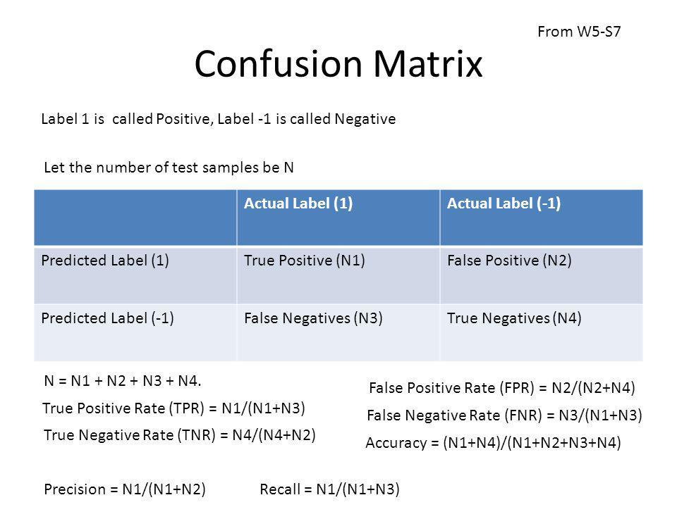

- Recall : 被模型正確分類為 Fraud 的個數 / 真實的 Fraud 的個數
- Precision : 被模型正確分類為 Fraud 的個數 / 被模型分類為 Fraud 的個數

因此，Imbalance Case 不能只使用 ACC 作為唯一模型評估方式。還要綜合 Recall & Precision 等指標來參考。

```r
> table(pred$class, test$Class)
```

```
        0     1
  0 84968    35
  1    16    99
```

### 除了 Threshold 為 0.5 ，那其他切點呢？

而剛剛我們討論的都是在 Threshold 為 0.5 的情況下，所進行分類的模型結果。如果我們要評估所有 Threshold 的分類結果時，有沒有什麼指標可以作為參考？

最常見的就是[AUC 指標](https://zh.wikipedia.org/wiki/ROC%E6%9B%B2%E7%BA%BF)。根據 AUC 一般定義：

- AUC=0.5 (no discrimination 無鑑別力)
- 0.7≦AUC≦0.8 (acceptable discrimination 可接受的鑑別力)
- 0.8≦AUC≦0.9 (excellent discrimination 優良的鑑別力)
- 0.9≦AUC≦1.0 (outstanding discrimination 極佳的鑑別力)

```r
> pr <- prediction(pred$posterior[,2], test$Class)
> auc_slot <- performance(pr,"auc") # ?performace 看看 measure 參數可以多少東西
> auc <- unlist(slot(auc_slot, "y.values"))
> auc %>% round(3)
```

```
[1] 0.971
```

ROC Curve ：

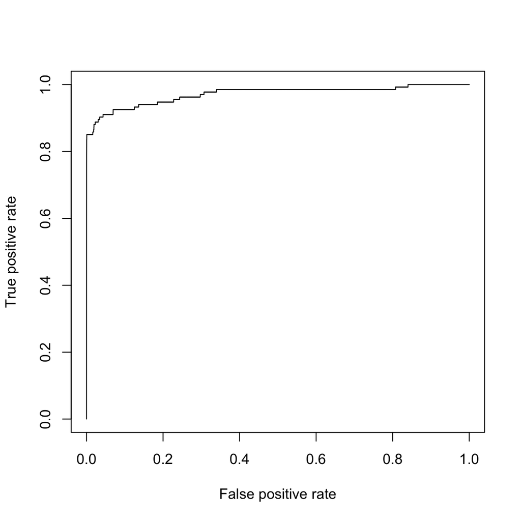

```r
> perf <- performance(pr,"tpr","fpr")
> plot(perf)
```

但其實到目前為止，AUC 對我們來說還不算是最好的指標。我們還需要另外一個指標，以就是 Kaggle 指定只用的 `AUPRC` (Area Under Precision-Recall Curve)，想要了解更多 ROC 與 PRC 的關係可以參考[這篇](http://pages.cs.wisc.edu/~jdavis/davisgoadrichcamera2.pdf)。而關於 AUPRC 在 R 中的使用方法則可以[參考這篇](https://cran.r-project.org/web/packages/PRROC/vignettes/PRROC.pdf)

文中提到：

> When dealing with highly skewed datasets, Precision-Recall(PR) curves give a more informative picture of an algorithm’s performance

### AUCPR

```r
> library("PRROC")
> lda.fit <- lda(Class ~ ., data = train)
> pred <- predict(lda.fit, newdata = test, type = "response")
> pr <- prediction(pred$posterior[,2], test$Class)
```

PR Curve :

> In PR space the goal is to be in the upper-right-hand corner。

對比於 ROC 會往左上，PR Curve 目標為往右上角逼近。而對於一個隨機的分類模型來說，AUC 會接近 0.5，而 PRAUC 會接近 0。

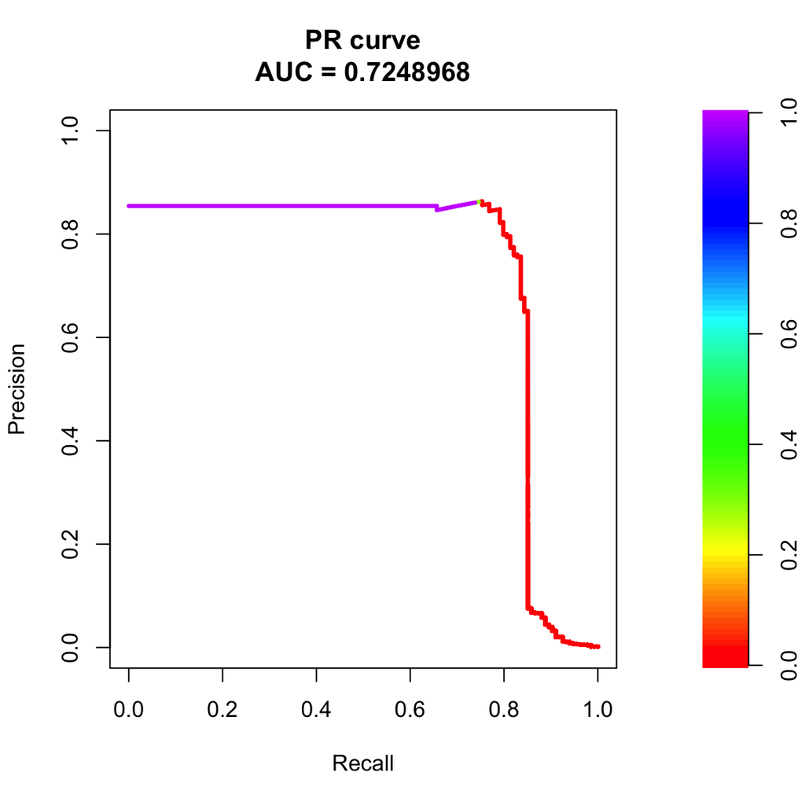

```r
> prc_dataFrame <- data.frame(pred, test$Class)
> prc <- pr.curve(prc_dataFrame[prc_dataFrame$test.Class == 1,]$posterior.1,
+                 prc_dataFrame[prc_dataFrame$test.Class == 0,]$posterior.1,
+                 curve = T)
> plot(prc)
```